# F1 vs. F0 cue-weighting in Children

# 1. Load necessary libraries 📚

# 2. Load data 📊

```r
# 1. Set the Working Directory 📁
# --------------------------------------------------------
# Set the working directory to the path where your data files are stored
setwd("/Users/jeremygenette_studio/Documents/Research/Code/IF0_babbling_lexical/Data/")
# 2. Load Data Files 📄
# --------------------------------------------------------
# Load the main data frame for analysis from an RDS file
df <-readRDS("/Users/jeremygenette_studio/Documents/Research/Code/IF0_babbling_lexical/Data/df_vf_for_analysis.rds")

# Load a supplementary data frame containing Child Babbling Ratio (CBR) data

df_CBR <-readRDS("/Users/jeremygenette_studio/Documents/Research/Code/IF0_babbling_lexical/Data/df_CBR.rds")

# 3. Round Numeric Columns in the Main Data Frame 🔢
# --------------------------------------------------------
# Round numeric columns to 3 decimal places, leaving other columns unchanged
df_RQ3 <- as.data.frame(lapply(df, function(x) if (is.numeric(x)) round(x, 3) else x))

# 4. Merge Data Frames 🔗
# --------------------------------------------------------
# Merge the main data frame with the CBR data frame by "CHILD" and "AGE"
df_RQ3 <- left_join(df_RQ3, df_CBR, by = c("CHILD", "AGE"))

# 5. Create "frontness" Column (Vowel Frontness) 🔤
# --------------------------------------------------------
# Assign vowel frontness based on the first character of the "vwl_nucl" column
df_RQ3$frt[df_RQ3$vwl_nucl %in% c("A", "u", "<")] <- "back"
df_RQ3$frt[df_RQ3$vwl_nucl %in% c("i", "a")] <- "front"

# Rename CHILD column with unique anonymous identifiers
if ("CHILD" %in% colnames(df_RQ3)) {
  df_RQ3$CHILD <- factor(df_RQ3$CHILD)  # Ensure it's a factor
  levels(df_RQ3$CHILD) <- paste("Child", seq_along(levels(df_RQ3$CHILD)))  # Rename levels
}


# Convert the "frontness" column to a factor
df_RQ3$frontness <- as.factor(df_RQ3$frt)

# 6. Filter, Transform, and Tidy the Data 🛠️
# --------------------------------------------------------
df_RQ3 <- df_RQ3 %>%
  filter(type == "lexical") %>%           # Retain only "prelexical" type rows
  group_by(CHILD) %>%                        # Group by "CHILD" for scaling
  mutate(
    item = as.factor(item),                 # Convert "item" to a factor
    hgt = as.factor(hgt),                   # Convert "hgt" (height) to a factor
    frt = as.factor(frontness),             # Convert "frontness" to a factor
    CHILD = as.factor(CHILD),               # Convert "CHILD" to a factor
    cumvoc = log(cumvoc),
    period = ifelse(AGE_ctrd <= 0, "prelexical", "lexical") # Define "period" based on CBR values
  ) %>%
  ungroup()  %>%
  select(
    -c(item, ID_vwl, type, F1_F0_distance, F0, F1, first_word, F1_F0_distance, frontness,frt)
  )  # Drop unnecessary columns

contrasts(df_RQ3$hgt) <- contr.sum(levels(df_RQ3$hgt))
df_RQ3$hgt <- relevel(df_RQ3$hgt, ref = "low")


# 7. Final Output Preview 🔍
# --------------------------------------------------------
# Print the first few rows of the preprocessed data frame
print(head(df_RQ3))
```

| CHILD | vwl_nucl | F0_Regression_Normalized | F1_Regression_Normalized | hgt | AGE | AGE.IN.DAYS | cumvoc | AGE_ctrd | CBR | period |
| --- | --- | --- | --- | --- | --- | --- | --- | --- | --- | --- |
| Child 1 | A | -0.404 | 0.135 | low | 14 | 435.25 | 0 | 0 | 0.27132 | prelexical |
| Child 1 | A | -0.273 | 0.141 | low | 14 | 435.25 | 0 | 0 | 0.27132 | prelexical |
| Child 1 | A | -0.326 | 0.048 | low | 14 | 435.25 | 0 | 0 | 0.27132 | prelexical |
| Child 1 | a | -0.409 | -0.034 | low | 14 | 435.25 | 0 | 0 | 0.27132 | prelexical |
| Child 1 | A | -0.334 | 0.063 | low | 14 | 435.25 | 0 | 0 | 0.27132 | prelexical |
| Child 1 | A | -0.258 | -0.096 | low | 14 | 435.25 | 0 | 0 | 0.27132 | prelexical |

```r
NA
```

# 3. Statistical Modelling 📊

### Model 1: Intercept-only Model

```r
m1 <- glmer(
  data = df_RQ3,
  formula = hgt ~ 1 + (1 | CHILD),
  family = binomial(link = "logit"),
  control = glmerControl(optimizer = "bobyqa", optCtrl = list(maxfun = 2000000))
)

saveRDS(m1, file = "models/m1_intercept_only_RQ3.rds")
```

### Model 2: Fixed Effect of F1

```r
m2_fixed_F1 <- glmer(
  data = df_RQ3,
  formula = hgt ~ F1_Regression_Normalized + (1 | CHILD),
  family = binomial(link = "logit"),
  control = glmerControl(optimizer = "bobyqa", optCtrl = list(maxfun = 10000000))
)

saveRDS(m2_fixed_F1, file = "models/m2_F1_fixed_effect_RQ3.rds")
anova_results_m2 <- anova(m1, m2_fixed_F1)
print(anova_results_m2)
```

```
Data: df_RQ3
Models:
m1: hgt ~ 1 + (1 | CHILD)
m2_fixed_F1: hgt ~ F1_Regression_Normalized + (1 | CHILD)
            npar   AIC   BIC  logLik deviance  Chisq Df Pr(>Chisq)
m1             2 14282 14297 -7138.9    14278
m2_fixed_F1    3 10495 10517 -5244.5    10489 3788.7  1  < 2.2e-16 ***
---
Signif. codes:  0 ‘***’ 0.001 ‘**’ 0.01 ‘*’ 0.05 ‘.’ 0.1 ‘ ’ 1
```

➡️ The added predictor F1_Regression_Normalized significantly improves the model fit and was retained for further analysis.

### Model 3: Random Slope for F1

```r
m3_random_slope_F1 <- glmer(
  data = df_RQ3,
  formula = hgt ~ F1_Regression_Normalized + (1 + F1_Regression_Normalized | CHILD),
  family = binomial(link = "logit"),
  control = glmerControl(optimizer = "bobyqa", optCtrl = list(maxfun = 10000000))
)

saveRDS(m3_random_slope_F1, file = "models/m3_random_slope_F1_RQ3.rds")
anova_results_m3 <- anova(m2_fixed_F1, m3_random_slope_F1)
print(anova_results_m3)
```

```
Data: df_RQ3
Models:
m2_fixed_F1: hgt ~ F1_Regression_Normalized + (1 | CHILD)
m3_random_slope_F1: hgt ~ F1_Regression_Normalized + (1 + F1_Regression_Normalized | CHILD)
                   npar   AIC   BIC  logLik deviance  Chisq Df Pr(>Chisq)
m2_fixed_F1           3 10495 10517 -5244.5    10489
m3_random_slope_F1    5 10363 10400 -5176.3    10353 136.45  2  < 2.2e-16 ***
---
Signif. codes:  0 ‘***’ 0.001 ‘**’ 0.01 ‘*’ 0.05 ‘.’ 0.1 ‘ ’ 1
```

➡️ The added random slope for F1_Regression_Normalized significantly improves the model fit and was retained for further analysis.

### Model 4: Fixed Effect of F0

```r
m4_fixed_F0 <- glmer(
  data = df_RQ3,
  formula = hgt ~ F1_Regression_Normalized + F0_Regression_Normalized + (1 + F1_Regression_Normalized | CHILD),
  family = binomial(link = "logit"),
  control = glmerControl(optimizer = "bobyqa", optCtrl = list(maxfun = 10000000))
)

saveRDS(m4_fixed_F0, file = "models/m4_fixed_F0_RQ3.rds")
anova_results_m4 <- anova(m3_random_slope_F1, m4_fixed_F0)
print(anova_results_m4)
```

```
Data: df_RQ3
Models:
m3_random_slope_F1: hgt ~ F1_Regression_Normalized + (1 + F1_Regression_Normalized | CHILD)
m4_fixed_F0: hgt ~ F1_Regression_Normalized + F0_Regression_Normalized + (1 + F1_Regression_Normalized | CHILD)
                   npar     AIC     BIC  logLik deviance  Chisq Df Pr(>Chisq)
m3_random_slope_F1    5 10362.6 10399.9 -5176.3  10352.6
m4_fixed_F0           6  9850.7  9895.5 -4919.4   9838.7 513.83  1  < 2.2e-16 ***
---
Signif. codes:  0 ‘***’ 0.001 ‘**’ 0.01 ‘*’ 0.05 ‘.’ 0.1 ‘ ’ 1
```

➡️ The added predictor F0_Regression_Normalized significantly improves the model fit and was retained for further analysis.

### Model 5: Random Slope for F0

```r
m5_random_slope_F0 <- glmer(
  data = df_RQ3,
  formula = hgt ~ F1_Regression_Normalized + F0_Regression_Normalized + (1 + F1_Regression_Normalized + F0_Regression_Normalized | CHILD),
  family = binomial(link = "logit"),
  control = glmerControl(optimizer = "bobyqa", optCtrl = list(maxfun = 10000000))
)

save(m5_random_slope_F0, file = "models/m5_random_slope_F0_RQ3.rds")
anova_results_m5 <- anova(m4_fixed_F0, m5_random_slope_F0)
print(anova_results_m5)
```

```
Data: df_RQ3
Models:
m4_fixed_F0: hgt ~ F1_Regression_Normalized + F0_Regression_Normalized + (1 + F1_Regression_Normalized | CHILD)
m5_random_slope_F0: hgt ~ F1_Regression_Normalized + F0_Regression_Normalized + (1 + F1_Regression_Normalized + F0_Regression_Normalized | CHILD)
                   npar    AIC    BIC  logLik deviance  Chisq Df Pr(>Chisq)
m4_fixed_F0           6 9850.7 9895.5 -4919.4   9838.7
m5_random_slope_F0    9 9728.8 9796.0 -4855.4   9710.8 127.96  3  < 2.2e-16 ***
---
Signif. codes:  0 ‘***’ 0.001 ‘**’ 0.01 ‘*’ 0.05 ‘.’ 0.1 ‘ ’ 1
```

➡️ The added random slope for F0_Regression_Normalized significantly improves the model fit and was retained for further analysis.

### Model 6: Fixed effect of cumvoc

```r
m6_fixed_frt <- glmer(
  data = df_RQ3,
  formula = hgt ~ F1_Regression_Normalized + F0_Regression_Normalized + cumvoc + (1 + F1_Regression_Normalized + F0_Regression_Normalized | CHILD),
  family = binomial(link = "logit"),
  control = glmerControl(optimizer = "bobyqa", optCtrl = list(maxfun = 10000000))
)

saveRDS(m6_fixed_frt, file = "models/m6_fixed_frt_RQ3.rds")
anova_results_m6 <- anova(m5_random_slope_F0, m6_fixed_frt)
print(anova_results_m6)
```

```
Data: df_RQ3
Models:
m5_random_slope_F0: hgt ~ F1_Regression_Normalized + F0_Regression_Normalized + (1 + F1_Regression_Normalized + F0_Regression_Normalized | CHILD)
m6_fixed_frt: hgt ~ F1_Regression_Normalized + F0_Regression_Normalized + cumvoc + (1 + F1_Regression_Normalized + F0_Regression_Normalized | CHILD)
                   npar    AIC    BIC  logLik deviance  Chisq Df Pr(>Chisq)
m5_random_slope_F0    9 9728.8 9796.0 -4855.4   9710.8
m6_fixed_frt         10 9717.1 9791.7 -4848.5   9697.1 13.702  1  0.0002143 ***
---
Signif. codes:  0 ‘***’ 0.001 ‘**’ 0.01 ‘*’ 0.05 ‘.’ 0.1 ‘ ’ 1
```

➡️ The added predictor cumvoc significantly improves the model fit and was retained for further analysis.

### Model 7: Random Slope for cumvoc

```r
m7_random_slope_cumvoc <- glmer(
  data = df_RQ3,
  formula = hgt ~ F1_Regression_Normalized + F0_Regression_Normalized + cumvoc + (1 + F1_Regression_Normalized + F0_Regression_Normalized  | CHILD)+(0+cumvoc|CHILD),
  family = binomial(link = "logit"),
  control = glmerControl(optimizer = "bobyqa", optCtrl = list(maxfun = 10000000))
)

saveRDS(m7_random_slope_cumvoc, file = "models/m7_random_slope_cumvoc_RQ3.rds")
anova_results_m7 <- anova(m6_fixed_frt, m7_random_slope_cumvoc)
print(anova_results_m7)
```

```
Data: df_RQ3
Models:
m6_fixed_frt: hgt ~ F1_Regression_Normalized + F0_Regression_Normalized + cumvoc + (1 + F1_Regression_Normalized + F0_Regression_Normalized | CHILD)
m7_random_slope_cumvoc: hgt ~ F1_Regression_Normalized + F0_Regression_Normalized + cumvoc + (1 + F1_Regression_Normalized + F0_Regression_Normalized | CHILD) + (0 + cumvoc | CHILD)
                       npar    AIC    BIC  logLik deviance  Chisq Df Pr(>Chisq)
m6_fixed_frt             10 9717.1 9791.7 -4848.5   9697.1
m7_random_slope_cumvoc   11 9690.6 9772.7 -4834.3   9668.6 28.524  1  9.255e-08 ***
---
Signif. codes:  0 ‘***’ 0.001 ‘**’ 0.01 ‘*’ 0.05 ‘.’ 0.1 ‘ ’ 1
```

➡️ The added random slope for cumvoc significantly improves the model fit and was retained for further analysis.

### Model 8: Quadratic effect of cumvoc

```r
m8_quadratic_cumvoc <- glmer(
  data = df_RQ3,
  formula = hgt ~ F1_Regression_Normalized + F0_Regression_Normalized + cumvoc + I(cumvoc^2)  + (1 + F1_Regression_Normalized + F0_Regression_Normalized   | CHILD)+(0+cumvoc|CHILD),
  family = binomial(link = "logit"),
  control = glmerControl(optimizer = "bobyqa", optCtrl = list(maxfun = 10000000))
)

saveRDS(m8_quadratic_cumvoc, file = "models/m8_quadratic_cumvoc_RQ3.rds")
anova_results_m8 <- anova(m7_random_slope_cumvoc, m8_quadratic_cumvoc)
print(anova_results_m8)
```

```
Data: df_RQ3
Models:
m7_random_slope_cumvoc: hgt ~ F1_Regression_Normalized + F0_Regression_Normalized + cumvoc + (1 + F1_Regression_Normalized + F0_Regression_Normalized | CHILD) + (0 + cumvoc | CHILD)
m8_quadratic_cumvoc: hgt ~ F1_Regression_Normalized + F0_Regression_Normalized + cumvoc + I(cumvoc^2) + (1 + F1_Regression_Normalized + F0_Regression_Normalized | CHILD) + (0 + cumvoc | CHILD)
                       npar    AIC    BIC  logLik deviance  Chisq Df Pr(>Chisq)
m7_random_slope_cumvoc   11 9690.6 9772.7 -4834.3   9668.6
m8_quadratic_cumvoc      12 9691.2 9780.8 -4833.6   9667.2 1.3164  1     0.2512
```

➡️ The added quadratic effect of cumvoc significantly did not improve the model fit and was not retained for further analysis.

### Model 9: Interaction between F1 and F0

```r
m9_interaction_F1_F0 <- glmer(
  data = df_RQ3,
  formula = hgt ~ F1_Regression_Normalized + F0_Regression_Normalized + F1_Regression_Normalized : F0_Regression_Normalized + cumvoc  + (1 + F1_Regression_Normalized + F0_Regression_Normalized   | CHILD)+(0+cumvoc|CHILD),
  family = binomial(link = "logit"),
  control = glmerControl(optimizer = "bobyqa", optCtrl = list(maxfun = 10000000))
)

saveRDS(m9_interaction_F1_F0, file = "models/m9_interaction_F1_F0_RQ3.rds")
anova_results_m9 <- anova(m7_random_slope_cumvoc, m9_interaction_F1_F0)
print(anova_results_m9)
```

```
Data: df_RQ3
Models:
m7_random_slope_cumvoc: hgt ~ F1_Regression_Normalized + F0_Regression_Normalized + cumvoc + (1 + F1_Regression_Normalized + F0_Regression_Normalized | CHILD) + (0 + cumvoc | CHILD)
m9_interaction_F1_F0: hgt ~ F1_Regression_Normalized + F0_Regression_Normalized + F1_Regression_Normalized:F0_Regression_Normalized + cumvoc + (1 + F1_Regression_Normalized + F0_Regression_Normalized | CHILD) + (0 + cumvoc | CHILD)
                       npar    AIC    BIC  logLik deviance  Chisq Df Pr(>Chisq)
m7_random_slope_cumvoc   11 9690.6 9772.7 -4834.3   9668.6
m9_interaction_F1_F0     12 9668.1 9757.7 -4822.1   9644.1 24.455  1  7.605e-07 ***
---
Signif. codes:  0 ‘***’ 0.001 ‘**’ 0.01 ‘*’ 0.05 ‘.’ 0.1 ‘ ’ 1
```

➡️ The added interaction between F1_Regression_Normalized and F0_Regression_Normalized significantly improves the model fit and was retained for further analysis.

### Model 10: Interaction between F1 and cumvoc

```r
m10_interaction_F1_cumvoc <- glmer(
  data = df_RQ3,
  formula = hgt ~ F1_Regression_Normalized + F0_Regression_Normalized + F1_Regression_Normalized : F0_Regression_Normalized + F1_Regression_Normalized : cumvoc + cumvoc  + (1 + F1_Regression_Normalized + F0_Regression_Normalized   | CHILD)+ (0+cumvoc|CHILD),
  family = binomial(link = "logit"),
  control = glmerControl(optimizer = "bobyqa", optCtrl = list(maxfun = 10000000))
)

saveRDS(m10_interaction_F1_cumvoc, file = "models/m10_interaction_F1_cumvoc_RQ3.rds")
anova_results_m10 <- anova(m9_interaction_F1_F0, m10_interaction_F1_cumvoc)
print(anova_results_m10)
```

```
Data: df_RQ3
Models:
m9_interaction_F1_F0: hgt ~ F1_Regression_Normalized + F0_Regression_Normalized + F1_Regression_Normalized:F0_Regression_Normalized + cumvoc + (1 + F1_Regression_Normalized + F0_Regression_Normalized | CHILD) + (0 + cumvoc | CHILD)
m10_interaction_F1_cumvoc: hgt ~ F1_Regression_Normalized + F0_Regression_Normalized + F1_Regression_Normalized:F0_Regression_Normalized + F1_Regression_Normalized:cumvoc + cumvoc + (1 + F1_Regression_Normalized + F0_Regression_Normalized | CHILD) + (0 + cumvoc | CHILD)
                          npar    AIC    BIC  logLik deviance  Chisq Df Pr(>Chisq)
m9_interaction_F1_F0        12 9668.1 9757.7 -4822.1   9644.1
m10_interaction_F1_cumvoc   13 9608.2 9705.2 -4791.1   9582.2 61.922  1  3.572e-15 ***
---
Signif. codes:  0 ‘***’ 0.001 ‘**’ 0.01 ‘*’ 0.05 ‘.’ 0.1 ‘ ’ 1
```

➡️ The added interaction between F1_Regression_Normalized and cumvoc significantly improves the model fit and was retained for further analysis.

### Model 11: Interaction between F1 and quadratic cumvoc

```r
m11_interaction_F1_quadratic_cumvoc <- glmer(
  data = df_RQ3,
  formula = hgt ~ F1_Regression_Normalized + F0_Regression_Normalized + F1_Regression_Normalized : F0_Regression_Normalized + F1_Regression_Normalized : (cumvoc +I(cumvoc^2)) + cumvoc  + (1 + F1_Regression_Normalized + F0_Regression_Normalized   | CHILD)+ (0+cumvoc|CHILD),
  family = binomial(link = "logit"),
  control = glmerControl(optimizer = "bobyqa", optCtrl = list(maxfun = 10000000))
)

saveRDS(m11_interaction_F1_quadratic_cumvoc, file = "models/m11_interaction_F1_quadratic_cumvoc_RQ3.rds")
anova_results_m11 <- anova(m10_interaction_F1_cumvoc, m11_interaction_F1_quadratic_cumvoc)
print(anova_results_m11)
```

```
Data: df_RQ3
Models:
m10_interaction_F1_cumvoc: hgt ~ F1_Regression_Normalized + F0_Regression_Normalized + F1_Regression_Normalized:F0_Regression_Normalized + F1_Regression_Normalized:cumvoc + cumvoc + (1 + F1_Regression_Normalized + F0_Regression_Normalized | CHILD) + (0 + cumvoc | CHILD)
m11_interaction_F1_quadratic_cumvoc: hgt ~ F1_Regression_Normalized + F0_Regression_Normalized + F1_Regression_Normalized:F0_Regression_Normalized + F1_Regression_Normalized:(cumvoc + I(cumvoc^2)) + cumvoc + (1 + F1_Regression_Normalized + F0_Regression_Normalized | CHILD) + (0 + cumvoc | CHILD)
                                    npar    AIC    BIC  logLik deviance  Chisq Df Pr(>Chisq)
m10_interaction_F1_cumvoc             13 9608.2 9705.2 -4791.1   9582.2
m11_interaction_F1_quadratic_cumvoc   14 9597.8 9702.3 -4784.9   9569.8 12.365  1  0.0004374 ***
---
Signif. codes:  0 ‘***’ 0.001 ‘**’ 0.01 ‘*’ 0.05 ‘.’ 0.1 ‘ ’ 1
```

➡️ The added interaction between F1_Regression_Normalized and quadratic cumvoc significantly improves the model fit and was retained for further analysis.

### Model 12: Interaction between F1 and cubic cumvoc

```r
m12_interaction_F1_cubic_cumvoc <- glmer(
  data = df_RQ3,
  formula = hgt ~ F1_Regression_Normalized + F0_Regression_Normalized + F1_Regression_Normalized : F0_Regression_Normalized + F1_Regression_Normalized : (cumvoc +I(cumvoc^2) + I(cumvoc^3)) + cumvoc  + (1 + F1_Regression_Normalized + F0_Regression_Normalized   | CHILD)+ (0+cumvoc|CHILD),
  family = binomial(link = "logit"),
  control = glmerControl(optimizer = "bobyqa", optCtrl = list(maxfun = 10000000))
)
saveRDS(m12_interaction_F1_cubic_cumvoc, file = "models/m12_interaction_F1_cubic_cumvoc_RQ3.rds")
anova_results_m12 <- anova(m11_interaction_F1_quadratic_cumvoc, m12_interaction_F1_cubic_cumvoc)
print(anova_results_m12)
```

```
Data: df_RQ3
Models:
m11_interaction_F1_quadratic_cumvoc: hgt ~ F1_Regression_Normalized + F0_Regression_Normalized + F1_Regression_Normalized:F0_Regression_Normalized + F1_Regression_Normalized:(cumvoc + I(cumvoc^2)) + cumvoc + (1 + F1_Regression_Normalized + F0_Regression_Normalized | CHILD) + (0 + cumvoc | CHILD)
m12_interaction_F1_cubic_cumvoc: hgt ~ F1_Regression_Normalized + F0_Regression_Normalized + F1_Regression_Normalized:F0_Regression_Normalized + F1_Regression_Normalized:(cumvoc + I(cumvoc^2) + I(cumvoc^3)) + cumvoc + (1 + F1_Regression_Normalized + F0_Regression_Normalized | CHILD) + (0 + cumvoc | …
                                    npar    AIC    BIC  logLik deviance  Chisq Df Pr(>Chisq)
m11_interaction_F1_quadratic_cumvoc   14 9597.8 9702.3 -4784.9   9569.8
m12_interaction_F1_cubic_cumvoc       15 9599.8 9711.8 -4784.9   9569.8 0.0047  1     0.9451
```

➡️ The added interaction between F1_Regression_Normalized and cubic cumvoc did not significantly improve the model fit and was not retained for further analysis.

### Model 13: Interaction between F0 and cumvoc

```r
m13_interaction_F0_cumvoc <- glmer(
  data = df_RQ3,
  formula = hgt ~ F1_Regression_Normalized + F0_Regression_Normalized + F1_Regression_Normalized : F0_Regression_Normalized + F1_Regression_Normalized : (cumvoc +I(cumvoc^2)) + F0_Regression_Normalized : cumvoc + cumvoc  + (1 + F1_Regression_Normalized + F0_Regression_Normalized   | CHILD)+ (0+cumvoc|CHILD),
  family = binomial(link = "logit"),
  control = glmerControl(optimizer = "bobyqa", optCtrl = list(maxfun = 10000000))
)
saveRDS(m13_interaction_F0_cumvoc, file = "models/m13_interaction_F0_cumvoc_RQ3.rds")
anova_results_m13 <- anova(m11_interaction_F1_quadratic_cumvoc, m13_interaction_F0_cumvoc)
print(anova_results_m13)
```

```
Data: df_RQ3
Models:
m11_interaction_F1_quadratic_cumvoc: hgt ~ F1_Regression_Normalized + F0_Regression_Normalized + F1_Regression_Normalized:F0_Regression_Normalized + F1_Regression_Normalized:(cumvoc + I(cumvoc^2)) + cumvoc + (1 + F1_Regression_Normalized + F0_Regression_Normalized | CHILD) + (0 + cumvoc | CHILD)
m13_interaction_F0_cumvoc: hgt ~ F1_Regression_Normalized + F0_Regression_Normalized + F1_Regression_Normalized:F0_Regression_Normalized + F1_Regression_Normalized:(cumvoc + I(cumvoc^2)) + F0_Regression_Normalized:cumvoc + cumvoc + (1 + F1_Regression_Normalized + F0_Regression_Normalized | CHILD) + …
                                    npar    AIC    BIC  logLik deviance  Chisq Df Pr(>Chisq)
m11_interaction_F1_quadratic_cumvoc   14 9597.8 9702.3 -4784.9   9569.8
m13_interaction_F0_cumvoc             15 9589.4 9701.4 -4779.7   9559.4 10.395  1   0.001264 **
---
Signif. codes:  0 ‘***’ 0.001 ‘**’ 0.01 ‘*’ 0.05 ‘.’ 0.1 ‘ ’ 1
```

➡️ The added interaction between F0_Regression_Normalized and cumvoc significantly improves the model fit and was retained for further analysis.

### Model 14: Interaction between F0 and quadratic cumvoc

```r
m14_interaction_F0_quadratic_cumvoc <- glmer(
  data = df_RQ3,
  formula = hgt ~ F1_Regression_Normalized + F0_Regression_Normalized + F1_Regression_Normalized : F0_Regression_Normalized + F1_Regression_Normalized : (cumvoc +I(cumvoc^2)) + F0_Regression_Normalized : (cumvoc +I(cumvoc^2)) + cumvoc  + (1 + F1_Regression_Normalized + F0_Regression_Normalized   | CHILD)+ (0+cumvoc|CHILD),
  family = binomial(link = "logit"),
  control = glmerControl(optimizer = "bobyqa", optCtrl = list(maxfun = 10000000))
)
saveRDS(m14_interaction_F0_quadratic_cumvoc, file = "models/m14_interaction_F0_quadratic_cumvoc_RQ3.rds")
anova_results_m14 <- anova(m13_interaction_F0_cumvoc, m14_interaction_F0_quadratic_cumvoc)
print(anova_results_m14)
```

```
Data: df_RQ3
Models:
m13_interaction_F0_cumvoc: hgt ~ F1_Regression_Normalized + F0_Regression_Normalized + F1_Regression_Normalized:F0_Regression_Normalized + F1_Regression_Normalized:(cumvoc + I(cumvoc^2)) + F0_Regression_Normalized:cumvoc + cumvoc + (1 + F1_Regression_Normalized + F0_Regression_Normalized | CHILD) + …
m14_interaction_F0_quadratic_cumvoc: hgt ~ F1_Regression_Normalized + F0_Regression_Normalized + F1_Regression_Normalized:F0_Regression_Normalized + F1_Regression_Normalized:(cumvoc + I(cumvoc^2)) + F0_Regression_Normalized:(cumvoc + I(cumvoc^2)) + cumvoc + (1 + F1_Regression_Normalized + F0_Regress…
                                    npar    AIC    BIC  logLik deviance  Chisq Df Pr(>Chisq)
m13_interaction_F0_cumvoc             15 9589.4 9701.4 -4779.7   9559.4
m14_interaction_F0_quadratic_cumvoc   16 9561.2 9680.6 -4764.6   9529.2 30.225  1  3.848e-08 ***
---
Signif. codes:  0 ‘***’ 0.001 ‘**’ 0.01 ‘*’ 0.05 ‘.’ 0.1 ‘ ’ 1
```

➡️ The added interaction between F0_Regression_Normalized and quadratic cumvoc significantly improves the model fit and was retained for further analysis.

### Model 15: Interaction between F0 and cubic cumvoc

```r
m15_interaction_F0_cubic_cumvoc <- glmer(
  data = df_RQ3,
  formula = hgt ~ F1_Regression_Normalized + F0_Regression_Normalized + F1_Regression_Normalized : F0_Regression_Normalized + F1_Regression_Normalized : (cumvoc +I(cumvoc^2) + I(cumvoc^3)) + F0_Regression_Normalized : (cumvoc +I(cumvoc^2) + I(cumvoc^3)) + cumvoc  + (1 + F1_Regression_Normalized + F0_Regression_Normalized   | CHILD)+ (0+cumvoc|CHILD),
  family = binomial(link = "logit"),
  control = glmerControl(optimizer = "bobyqa", optCtrl = list(maxfun = 10000000))
)

saveRDS(m15_interaction_F0_cubic_cumvoc, file = "models/m15_interaction_F0_cubic_cumvoc_RQ3.rds")
anova_results_m15 <- anova(m15_interaction_F0_cubic_cumvoc, m14_interaction_F0_quadratic_cumvoc)
print(anova_results_m15)
```

```
Data: df_RQ3
Models:
m14_interaction_F0_quadratic_cumvoc: hgt ~ F1_Regression_Normalized + F0_Regression_Normalized + F1_Regression_Normalized:F0_Regression_Normalized + F1_Regression_Normalized:(cumvoc + I(cumvoc^2)) + F0_Regression_Normalized:(cumvoc + I(cumvoc^2)) + cumvoc + (1 + F1_Regression_Normalized + F0_Regress…
m15_interaction_F0_cubic_cumvoc: hgt ~ F1_Regression_Normalized + F0_Regression_Normalized + F1_Regression_Normalized:F0_Regression_Normalized + F1_Regression_Normalized:(cumvoc + I(cumvoc^2) + I(cumvoc^3)) + F0_Regression_Normalized:(cumvoc + I(cumvoc^2) + I(cumvoc^3)) + cumvoc + (1 + F1_Regression…
                                    npar    AIC    BIC  logLik deviance  Chisq Df Pr(>Chisq)
m14_interaction_F0_quadratic_cumvoc   16 9561.2 9680.6 -4764.6   9529.2
m15_interaction_F0_cubic_cumvoc       18 9564.0 9698.4 -4764.0   9528.0 1.2009  2     0.5486
```

➡️ The added interaction between F0_Regression_Normalized and cubic cumvoc did not significantly improve the model fit and was not retained for further analysis.

### Model 16: Interaction between F1 and F0 and cumvoc

```r
m16_interaction_F1_F0_cumvoc <- glmer(
  data = df_RQ3,
  formula = hgt ~ F1_Regression_Normalized + F0_Regression_Normalized + F1_Regression_Normalized : F0_Regression_Normalized + F1_Regression_Normalized : (cumvoc +I(cumvoc^2)) + F0_Regression_Normalized : (cumvoc +I(cumvoc^2)) + F1_Regression_Normalized : F0_Regression_Normalized : cumvoc + cumvoc  + (1 + F1_Regression_Normalized + F0_Regression_Normalized   | CHILD)+ (0+cumvoc|CHILD),
  family = binomial(link = "logit"),
  control = glmerControl(optimizer = "bobyqa", optCtrl = list(maxfun = 10000000))
)

saveRDS(m16_interaction_F1_F0_cumvoc, file = "models/m16_interaction_F1_F0_cumvoc_RQ3.rds")
anova_results_m16 <- anova(m16_interaction_F1_F0_cumvoc, m14_interaction_F0_quadratic_cumvoc)
print(anova_results_m16)
```

```
Data: df_RQ3
Models:
m14_interaction_F0_quadratic_cumvoc: hgt ~ F1_Regression_Normalized + F0_Regression_Normalized + F1_Regression_Normalized:F0_Regression_Normalized + F1_Regression_Normalized:(cumvoc + I(cumvoc^2)) + F0_Regression_Normalized:(cumvoc + I(cumvoc^2)) + cumvoc + (1 + F1_Regression_Normalized + F0_Regress…
m16_interaction_F1_F0_cumvoc: hgt ~ F1_Regression_Normalized + F0_Regression_Normalized + F1_Regression_Normalized:F0_Regression_Normalized + F1_Regression_Normalized:(cumvoc + I(cumvoc^2)) + F0_Regression_Normalized:(cumvoc + I(cumvoc^2)) + F1_Regression_Normalized:F0_Regression_Normalized:cumvoc +…
                                    npar    AIC    BIC  logLik deviance  Chisq Df Pr(>Chisq)
m14_interaction_F0_quadratic_cumvoc   16 9561.2 9680.6 -4764.6   9529.2
m16_interaction_F1_F0_cumvoc          17 9563.2 9690.1 -4764.6   9529.2 0.0199  1     0.8878
```

➡️ The added interaction between F1_Regression_Normalized, F0_Regression_Normalized, and cumvoc did not significantly improve the model fit and was not retained for further analysis.

# 4. Results Summary 📊

```r
final_model <- m14_interaction_F0_quadratic_cumvoc
print(summary(final_model))
```

```
Generalized linear mixed model fit by maximum likelihood (Laplace Approximation) ['glmerMod']
 Family: binomial  ( logit )
Formula: hgt ~ F1_Regression_Normalized + F0_Regression_Normalized + F1_Regression_Normalized:F0_Regression_Normalized +
    F1_Regression_Normalized:(cumvoc + I(cumvoc^2)) + F0_Regression_Normalized:(cumvoc +
    I(cumvoc^2)) + cumvoc + (1 + F1_Regression_Normalized + F0_Regression_Normalized |      CHILD) + (0 + cumvoc | CHILD)
   Data: df_RQ3
Control: glmerControl(optimizer = "bobyqa", optCtrl = list(maxfun = 1e+07))

     AIC      BIC   logLik deviance df.resid
  9561.2   9680.6  -4764.6   9529.2    12890

Scaled residuals:
    Min      1Q  Median      3Q     Max
 -5.129  -0.407  -0.197   0.252 106.116

Random effects:
 Groups  Name                     Variance Std.Dev. Corr
 CHILD   (Intercept)              1.53607  1.239
         F1_Regression_Normalized 2.91366  1.707     0.33
         F0_Regression_Normalized 2.80489  1.675    -0.21 -0.08
 CHILD.1 cumvoc                   0.06607  0.257
Number of obs: 12906, groups:  CHILD, 30

Fixed effects:
                                                  Estimate Std. Error z value Pr(>|z|)
(Intercept)                                       -1.55644    0.28634  -5.436 5.46e-08 ***
F1_Regression_Normalized                          -5.92385    1.17463  -5.043 4.58e-07 ***
F0_Regression_Normalized                           4.59021    0.92196   4.979 6.40e-07 ***
cumvoc                                             0.17993    0.06189   2.907  0.00365 **
F1_Regression_Normalized:F0_Regression_Normalized -2.48910    0.62440  -3.986 6.71e-05 ***
F1_Regression_Normalized:cumvoc                    1.08787    0.63422   1.715  0.08629 .
F1_Regression_Normalized:I(cumvoc^2)              -0.34203    0.08737  -3.915 9.05e-05 ***
F0_Regression_Normalized:cumvoc                   -1.87603    0.50445  -3.719  0.00020 ***
F0_Regression_Normalized:I(cumvoc^2)               0.36071    0.07349   4.909 9.18e-07 ***
---
Signif. codes:  0 ‘***’ 0.001 ‘**’ 0.01 ‘*’ 0.05 ‘.’ 0.1 ‘ ’ 1

Correlation of Fixed Effects:
            (Intr) F1_Rg_N F0_Rg_N cumvoc F1_R_N:F F1_Rg_N: F1_R_N:I F0_Rg_N:
F1_Rgrssn_N  0.079
F0_Rgrssn_N  0.036 -0.164
cumvoc      -0.391 -0.016  -0.090
F1_R_N:F0_R -0.018  0.266  -0.048   0.009
F1_Rgrss_N: -0.035 -0.899   0.126   0.038 -0.275
F1_R_N:I(^2  0.048  0.802  -0.098  -0.052  0.236   -0.972
F0_Rgrss_N: -0.122  0.130  -0.854   0.119 -0.023   -0.123    0.113
F0_R_N:I(^2  0.128 -0.102   0.737  -0.129  0.049    0.111   -0.114   -0.967
```

```r
save.image("/Users/jeremygenette_studio/Documents/Research/Code/IF0_babbling_lexical/image_RQ3.Rdata")
```

# 5. Plotting the Results 📈

[figure not shown]

```r
# Define color palettes
F1_color <- c("#9F3400", "#FF681F", "#FFBE9F")
F0_color <- c("#570987", "#A020F0", "#D397F8")

# Define a function for plotting
create_plot <- function(model, term1, term2, colors, y_label, x_label, legend_title) {
  plot <- plot_model(model, type = "pred", terms = c("cumvoc [all]", term2, term1), pred.type = "fe") +
    labs(
      color = legend_title,
      y = y_label,
      x = x_label,
      title = ""
    ) +
    theme_cowplot() +
    scale_color_manual(values = colors) +
    scale_fill_manual(values = colors) +
    scale_y_continuous(labels = scales::percent_format(), limits = c(0, 1)) +
    theme(legend.position = "bottom", legend.box = "horizontal")
  return(plot)
}

# Ensure the 'graph' folder exists
if (!dir.exists("graph")) dir.create("graph")

# Create and save plots for F1
plot_f1 <- create_plot(
  final_model,
  term1 = "CHILD",
  term2 = "F1_Regression_Normalized",
  colors = F1_color,
  y_label = "Predicted probability of a vowel being high",
  x_label = "log (cumvoc)",
  legend_title = "Normalized F1"
)
plot_f1
ggsave("graph/RQ3_plot_F1_child.png", plot_f1, width = 8, height = 8, dpi = 300)
```

[figure not shown]

```r
# Create and save plots for F0
plot_f0 <- create_plot(
  final_model,
  term1 = "CHILD",
  term2 = "F0_Regression_Normalized",
  colors = F0_color,
  y_label = "Predicted probability of a vowel being high",
  x_label = "log (cumvoc)",
  legend_title = "Normalized F0"
)
plot_f0
ggsave("graph/RQ3_plot_F0_child.png", plot_f0, width = 8, height = 8, dpi = 300)
```

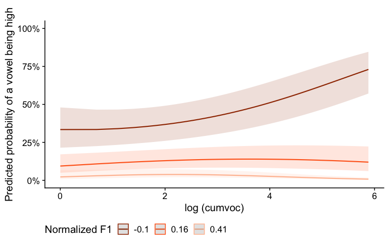

```r
# Create and save plots for F1 without CHILD factor
plot_f1_no_child <- create_plot(
  final_model,
  term1 = NULL,
  term2 = "F1_Regression_Normalized",
  colors = F1_color,
  y_label = "Predicted probability of a vowel being high",
  x_label = "log (cumvoc)",
  legend_title = "Normalized F1"
)
plot_f1_no_child
ggsave("graph/RQ3_plot_F1.png", plot_f1_no_child, width = 8, height = 6, dpi = 300)
```

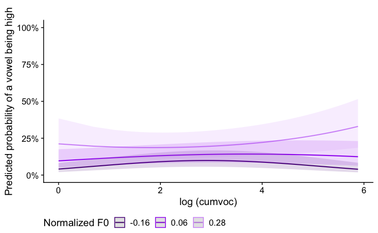

```r
# Create and save plots for F0 without CHILD factor
plot_f0_no_child <- create_plot(
  final_model,
  term1 = NULL,
  term2 = "F0_Regression_Normalized",
  colors = F0_color,
  y_label = "Predicted probability of a vowel being high",
  x_label = "log (cumvoc)",
  legend_title = "Normalized F0"
)
plot_f0_no_child
ggsave("graph/RQ3_plot_F0.png", plot_f0_no_child, width = 8, height = 6, dpi = 300)
```